# Housing Price Growth Regression Analysis

Yarida Kaewthong

2026-05-15

# 1. Load and Prepare Data

```r
data <- read.csv("data_new.csv", check.names = FALSE, row.names = NULL)

names(data)
```

```
##  [1] "Year"                       "QuarterDate"
##  [3] "Quarter"                    "City"
##  [5] "State"                      "MeanDwellingPrice($000)"
##  [7] "HPGrowth_pct(%)"            "InterestRate(%)"
##  [9] "Inflation(%)"               "NetOverseasMigration"
## [11] "HouseholdIncome_per_capita" "Covid19"
## [13] "Election_dummy"             "Quarter2"
## [15] "Quarter3"                   "Quarter4"
## [17] "Time Trend"
```

```r
data_clean <- data[, c(
  "Year",
  "QuarterDate",
  "Quarter",
  "City",
  "State",
  "HPGrowth_pct(%)",
  "InterestRate(%)",
  "Inflation(%)",
  "NetOverseasMigration",
  "HouseholdIncome_per_capita",
  "Covid19",
  "Election_dummy",
  "Quarter2",
  "Quarter3",
  "Quarter4",
  "Time Trend"
)]

data_clean$State <- as.factor(data_clean$State)
data_clean$State <- relevel(data_clean$State, ref = "SA")

head(data_clean)
```

```
##   Year QuarterDate Quarter   City State HPGrowth_pct(%) InterestRate(%)
## 1 2014       46187      Q2 Sydney   NSW            2.96            2.50
## 2 2014       46279      Q3 Sydney   NSW            2.55            2.50
## 3 2014       46370      Q4 Sydney   NSW            4.05            2.50
## 4 2015       46096      Q1 Sydney   NSW            3.56            2.25
## 5 2015       46188      Q2 Sydney   NSW            5.95            2.00
## 6 2015       46280      Q3 Sydney   NSW            3.57            2.00
##   Inflation(%) NetOverseasMigration HouseholdIncome_per_capita Covid19
## 1          0.5                11375                      45068       0
## 2          0.4                19303                      45068       0
## 3          0.2                15869                      45068       0
## 4          0.2                22897                      46965       0
## 5          0.7                12240                      46965       0
## 6          0.4                20471                      46965       0
##   Election_dummy Quarter2 Quarter3 Quarter4 Time Trend
## 1              0        1        0        0          1
## 2              0        0        1        0          2
## 3              0        0        0        1          3
## 4              0        0        0        0          4
## 5              0        1        0        0          5
## 6              0        0        1        0          6
```

# 2. Regression Models

## Model 1: Baseline Time-Control Model

This model includes time trend, quarterly seasonality, and state controls.

```r
model1 <- lm(
  `HPGrowth_pct(%)` ~ Quarter2 + Quarter3 + Quarter4 + `Time Trend` + State,
  data = data_clean
)

summary(model1)
```

```
##
## Call:
## lm(formula = `HPGrowth_pct(%)` ~ Quarter2 + Quarter3 + Quarter4 +
##     `Time Trend` + State, data = data_clean)
##
## Residuals:
##     Min      1Q  Median      3Q     Max
## -8.6394 -1.7744 -0.2024  1.8158  7.3922
##
## Coefficients:
##              Estimate Std. Error t value Pr(>|t|)
## (Intercept)   0.99964    0.59947   1.668  0.09682 .
## Quarter2      0.02856    0.50164   0.057  0.95465
## Quarter3     -0.99838    0.50146  -1.991  0.04772 *
## Quarter4      0.27056    0.51242   0.528  0.59802
## `Time Trend`  0.04111    0.01335   3.079  0.00234 **
## StateNSW     -0.16957    0.56012  -0.303  0.76238
## StateQLD      0.06326    0.56012   0.113  0.91018
## StateVIC     -0.58261    0.56012  -1.040  0.29941
## StateWA      -0.69957    0.56012  -1.249  0.21300
## ---
## Signif. codes:  0 '***' 0.001 '**' 0.01 '*' 0.05 '.' 0.1 ' ' 1
##
## Residual standard error: 2.686 on 221 degrees of freedom
## Multiple R-squared:  0.08228,    Adjusted R-squared:  0.04906
## F-statistic: 2.477 on 8 and 221 DF,  p-value: 0.01367
```

## Model 2: Adding Interest Rate and Inflation

This model adds basic macroeconomic variables.

```r
model2 <- lm(
  `HPGrowth_pct(%)` ~ `InterestRate(%)` + `Inflation(%)` +
    Quarter2 + Quarter3 + Quarter4 + `Time Trend` + State,
  data = data_clean
)

summary(model2)
```

```
##
## Call:
## lm(formula = `HPGrowth_pct(%)` ~ `InterestRate(%)` + `Inflation(%)` +
##     Quarter2 + Quarter3 + Quarter4 + `Time Trend` + State, data = data_clean)
##
## Residuals:
##     Min      1Q  Median      3Q     Max
## -9.1871 -1.6912  0.0443  1.7127  6.1942
##
## Coefficients:
##                   Estimate Std. Error t value Pr(>|t|)
## (Intercept)        1.24285    0.59993   2.072  0.03947 *
## `InterestRate(%)` -0.41629    0.13607  -3.059  0.00249 **
## `Inflation(%)`     0.62083    0.30425   2.041  0.04250 *
## Quarter2           0.16474    0.48957   0.337  0.73681
## Quarter3          -1.04416    0.49030  -2.130  0.03432 *
## Quarter4           0.26747    0.49855   0.537  0.59216
## `Time Trend`       0.04732    0.01560   3.034  0.00271 **
## StateNSW          -0.16957    0.54433  -0.312  0.75571
## StateQLD           0.06326    0.54433   0.116  0.90759
## StateVIC          -0.58261    0.54433  -1.070  0.28565
## StateWA           -0.69957    0.54433  -1.285  0.20008
## ---
## Signif. codes:  0 '***' 0.001 '**' 0.01 '*' 0.05 '.' 0.1 ' ' 1
##
## Residual standard error: 2.61 on 219 degrees of freedom
## Multiple R-squared:  0.1412, Adjusted R-squared:  0.1019
## F-statistic: 3.599 on 10 and 219 DF,  p-value: 0.0001904
```

## Model 3: Adding Migration and Household Income

This model adds net overseas migration and household income.

```r
model3 <- lm(
  `HPGrowth_pct(%)` ~ `InterestRate(%)` + `Inflation(%)` +
    NetOverseasMigration + HouseholdIncome_per_capita +
    Quarter2 + Quarter3 + Quarter4 + `Time Trend` + State,
  data = data_clean
)

summary(model3)
```

```
##
## Call:
## lm(formula = `HPGrowth_pct(%)` ~ `InterestRate(%)` + `Inflation(%)` +
##     NetOverseasMigration + HouseholdIncome_per_capita + Quarter2 +
##     Quarter3 + Quarter4 + `Time Trend` + State, data = data_clean)
##
## Residuals:
##     Min      1Q  Median      3Q     Max
## -7.2578 -1.5965 -0.0651  1.4197  6.3146
##
## Coefficients:
##                              Estimate Std. Error t value Pr(>|t|)
## (Intercept)                 2.132e+00  3.702e+00   0.576 0.565336
## `InterestRate(%)`           4.109e-02  1.724e-01   0.238 0.811829
## `Inflation(%)`              1.129e+00  3.208e-01   3.520 0.000526 ***
## NetOverseasMigration       -1.161e-04  2.210e-05  -5.254 3.55e-07 ***
## HouseholdIncome_per_capita -2.561e-05  9.835e-05  -0.260 0.794767
## Quarter2                   -7.509e-01  4.953e-01  -1.516 0.130946
## Quarter3                   -1.705e+00  4.888e-01  -3.488 0.000590 ***
## Quarter4                   -6.296e-01  5.198e-01  -1.211 0.227118
## `Time Trend`                5.132e-02  3.515e-02   1.460 0.145687
## StateNSW                    2.115e+00  1.047e+00   2.020 0.044586 *
## StateQLD                    7.678e-01  6.083e-01   1.262 0.208277
## StateVIC                    1.258e+00  6.545e-01   1.922 0.055958 .
## StateWA                    -1.240e-01  1.216e+00  -0.102 0.918901
## ---
## Signif. codes:  0 '***' 0.001 '**' 0.01 '*' 0.05 '.' 0.1 ' ' 1
##
## Residual standard error: 2.469 on 217 degrees of freedom
## Multiple R-squared:  0.2387, Adjusted R-squared:  0.1967
## F-statistic: 5.671 on 12 and 217 DF,  p-value: 1.813e-08
```

## Model 4: Adding COVID-19

This model adds the COVID-19 dummy variable.

```r
model4 <- lm(
  `HPGrowth_pct(%)` ~ `InterestRate(%)` + `Inflation(%)` +
    NetOverseasMigration + HouseholdIncome_per_capita + Covid19 +
    Quarter2 + Quarter3 + Quarter4 + `Time Trend` + State,
  data = data_clean
)

summary(model4)
```

```
##
## Call:
## lm(formula = `HPGrowth_pct(%)` ~ `InterestRate(%)` + `Inflation(%)` +
##     NetOverseasMigration + HouseholdIncome_per_capita + Covid19 +
##     Quarter2 + Quarter3 + Quarter4 + `Time Trend` + State, data = data_clean)
##
## Residuals:
##     Min      1Q  Median      3Q     Max
## -7.5162 -1.4915 -0.0004  1.4585  7.0000
##
## Coefficients:
##                              Estimate Std. Error t value Pr(>|t|)
## (Intercept)                 2.498e+00  3.608e+00   0.692 0.489398
## `InterestRate(%)`           5.227e-01  2.155e-01   2.426 0.016105 *
## `Inflation(%)`              1.458e+00  3.258e-01   4.475 1.24e-05 ***
## NetOverseasMigration       -8.183e-05  2.358e-05  -3.470 0.000629 ***
## HouseholdIncome_per_capita -5.775e-05  9.622e-05  -0.600 0.548979
## Covid19                     2.633e+00  7.385e-01   3.566 0.000447 ***
## Quarter2                   -4.579e-01  4.894e-01  -0.936 0.350450
## Quarter3                   -1.650e+00  4.764e-01  -3.464 0.000642 ***
## Quarter4                   -5.053e-01  5.075e-01  -0.996 0.320501
## `Time Trend`                1.887e-02  3.542e-02   0.533 0.594829
## StateNSW                    1.751e+00  1.025e+00   1.708 0.089096 .
## StateQLD                    6.747e-01  5.931e-01   1.138 0.256540
## StateVIC                    7.845e-01  6.512e-01   1.205 0.229657
## StateWA                     1.472e-01  1.187e+00   0.124 0.901434
## ---
## Signif. codes:  0 '***' 0.001 '**' 0.01 '*' 0.05 '.' 0.1 ' ' 1
##
## Residual standard error: 2.405 on 216 degrees of freedom
## Multiple R-squared:  0.2811, Adjusted R-squared:  0.2378
## F-statistic: 6.496 on 13 and 216 DF,  p-value: 2.211e-10
```

## Model 5: Adding Election Dummy

This model adds the election dummy variable.

```r
model5 <- lm(
  `HPGrowth_pct(%)` ~ `InterestRate(%)` + `Inflation(%)` +
    NetOverseasMigration + HouseholdIncome_per_capita + Covid19 +
    Election_dummy + Quarter2 + Quarter3 + Quarter4 +
    `Time Trend` + State,
  data = data_clean
)

summary(model5)
```

```
##
## Call:
## lm(formula = `HPGrowth_pct(%)` ~ `InterestRate(%)` + `Inflation(%)` +
##     NetOverseasMigration + HouseholdIncome_per_capita + Covid19 +
##     Election_dummy + Quarter2 + Quarter3 + Quarter4 + `Time Trend` +
##     State, data = data_clean)
##
## Residuals:
##     Min      1Q  Median      3Q     Max
## -7.4381 -1.4730  0.0112  1.4577  7.0622
##
## Coefficients:
##                              Estimate Std. Error t value Pr(>|t|)
## (Intercept)                 2.166e+00  3.660e+00   0.592 0.554530
## `InterestRate(%)`           4.432e-01  2.568e-01   1.726 0.085746 .
## `Inflation(%)`              1.446e+00  3.270e-01   4.424 1.54e-05 ***
## NetOverseasMigration       -8.191e-05  2.362e-05  -3.468 0.000634 ***
## HouseholdIncome_per_capita -4.478e-05  9.900e-05  -0.452 0.651478
## Covid19                     2.343e+00  8.966e-01   2.614 0.009589 **
## Election_dummy             -2.544e-01  4.452e-01  -0.571 0.568285
## Quarter2                   -4.586e-01  4.902e-01  -0.936 0.350542
## Quarter3                   -1.643e+00  4.773e-01  -3.442 0.000693 ***
## Quarter4                   -5.041e-01  5.083e-01  -0.992 0.322403
## `Time Trend`                2.009e-02  3.554e-02   0.565 0.572514
## StateNSW                    1.651e+00  1.041e+00   1.585 0.114444
## StateQLD                    6.376e-01  5.976e-01   1.067 0.287231
## StateVIC                    7.627e-01  6.534e-01   1.167 0.244377
## StateWA                     3.260e-03  1.215e+00   0.003 0.997862
## ---
## Signif. codes:  0 '***' 0.001 '**' 0.01 '*' 0.05 '.' 0.1 ' ' 1
##
## Residual standard error: 2.409 on 215 degrees of freedom
## Multiple R-squared:  0.2822, Adjusted R-squared:  0.2354
## F-statistic: 6.036 on 14 and 215 DF,  p-value: 5.065e-10
```

# 3. Model Comparison

```r
get_f_pvalue <- function(model) {
  f <- summary(model)$fstatistic
  pf(f[1], f[2], f[3], lower.tail = FALSE)
}

comparison <- data.frame(
  Model = c("Model 1", "Model 2", "Model 3", "Model 4", "Model 5"),
  R_Squared = c(
    summary(model1)$r.squared,
    summary(model2)$r.squared,
    summary(model3)$r.squared,
    summary(model4)$r.squared,
    summary(model5)$r.squared
  ),
  Adjusted_R_Squared = c(
    summary(model1)$adj.r.squared,
    summary(model2)$adj.r.squared,
    summary(model3)$adj.r.squared,
    summary(model4)$adj.r.squared,
    summary(model5)$adj.r.squared
  ),
  Significance_F = c(
    get_f_pvalue(model1),
    get_f_pvalue(model2),
    get_f_pvalue(model3),
    get_f_pvalue(model4),
    get_f_pvalue(model5)
  )
)

comparison
```

```
##     Model  R_Squared Adjusted_R_Squared Significance_F
## 1 Model 1 0.08228208         0.04906153   1.367186e-02
## 2 Model 2 0.14115414         0.10193743   1.903622e-04
## 3 Model 3 0.23874752         0.19665061   1.813443e-08
## 4 Model 4 0.28106237         0.23779298   2.210980e-10
## 5 Model 5 0.28215272         0.23540917   5.065250e-10
```

Model 4 is selected as the preferred model because it has the highest adjusted R-squared value. Although Model 5 has a slightly higher R-squared, its adjusted R-squared decreases after adding the election dummy variable. The election dummy is also not statistically significant.

# 4. Prediction Accuracy

```r
get_accuracy <- function(model, data) {
  predicted <- predict(model)
  actual <- data$`HPGrowth_pct(%)`
  residual <- actual - predicted

  rmse <- sqrt(mean(residual^2))
  mae <- mean(abs(residual))

  return(c(RMSE = rmse, MAE = mae))
}

accuracy_table <- data.frame(
  Model = c("Model 1", "Model 2", "Model 3", "Model 4", "Model 5"),
  rbind(
    get_accuracy(model1, data_clean),
    get_accuracy(model2, data_clean),
    get_accuracy(model3, data_clean),
    get_accuracy(model4, data_clean),
    get_accuracy(model5, data_clean)
  )
)

accuracy_table
```

```
##     Model     RMSE      MAE
## 1 Model 1 2.633162 2.030827
## 2 Model 2 2.547303 1.986468
## 3 Model 3 2.398211 1.862411
## 4 Model 4 2.330605 1.787045
## 5 Model 5 2.328837 1.790918
```

RMSE and MAE were calculated to compare prediction accuracy. Lower values indicate better predictive performance. MAPE was not used because housing price growth includes negative and near-zero values.

# 5. Actual vs Predicted Graphs

```r
data_clean$QuarterLabel <- ifelse(data_clean$Quarter2 == 1, "Q2",
                           ifelse(data_clean$Quarter3 == 1, "Q3",
                           ifelse(data_clean$Quarter4 == 1, "Q4", "Q1")))

data_clean$QuarterDate <- as.Date(
  paste(
    data_clean$Year,
    ifelse(data_clean$QuarterLabel == "Q1", "01-01",
    ifelse(data_clean$QuarterLabel == "Q2", "04-01",
    ifelse(data_clean$QuarterLabel == "Q3", "07-01", "10-01"))),
    sep = "-"
  )
)

data_clean$Predicted_Model4 <- predict(model4)
```

```r
plot_state <- function(state_name) {

  state_data <- subset(data_clean, State == state_name)

  ggplot(state_data, aes(x = QuarterDate)) +
    annotate(
      "rect",
      xmin = min(state_data$QuarterDate[state_data$Covid19 == 1]),
      xmax = max(state_data$QuarterDate[state_data$Covid19 == 1]),
      ymin = -Inf,
      ymax = Inf,
      alpha = 0.15,
      fill = "grey"
    ) +
    geom_line(aes(y = `HPGrowth_pct(%)`, colour = "Actual HPGrowth"), linewidth = 1) +
    geom_point(aes(y = `HPGrowth_pct(%)`, colour = "Actual HPGrowth"), size = 1.5) +
    geom_line(aes(y = Predicted_Model4, colour = "Predicted HPGrowth"),
              linewidth = 1, linetype = "dashed") +
    geom_point(aes(y = Predicted_Model4, colour = "Predicted HPGrowth"), size = 1.5) +
    scale_colour_manual(
      values = c(
        "Actual HPGrowth" = "steelblue",
        "Predicted HPGrowth" = "darkorange"
      )
    ) +
    scale_x_date(date_breaks = "1 year", date_labels = "%Y") +
    labs(
      title = paste("Model 4: Actual vs Predicted Quarterly Housing Price Growth in", state_name),
      subtitle = "Each point represents one quarter; grey area represents the COVID-19 period",
      x = "Year",
      y = "Housing Price Growth (%)",
      colour = ""
    ) +
    theme_minimal() +
    theme(
      plot.title = element_text(size = 14, face = "bold"),
      plot.subtitle = element_text(size = 10),
      axis.text.x = element_text(angle = 45, hjust = 1),
      legend.position = "bottom"
    )
}
```

## NSW

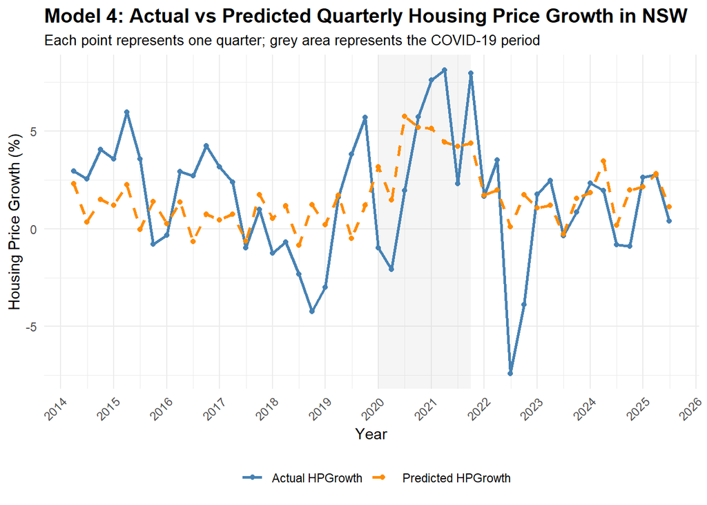

```r
plot_state("NSW")
```

## VIC

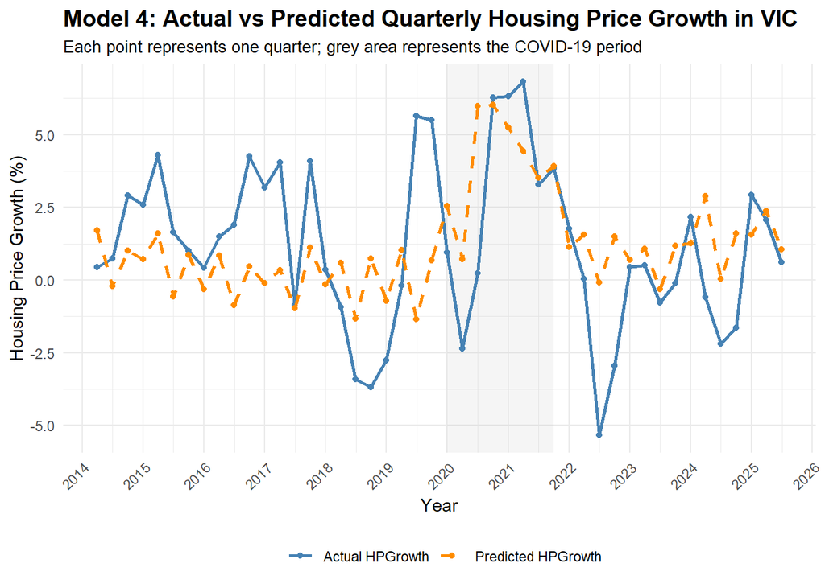

```r
plot_state("VIC")
```

## QLD

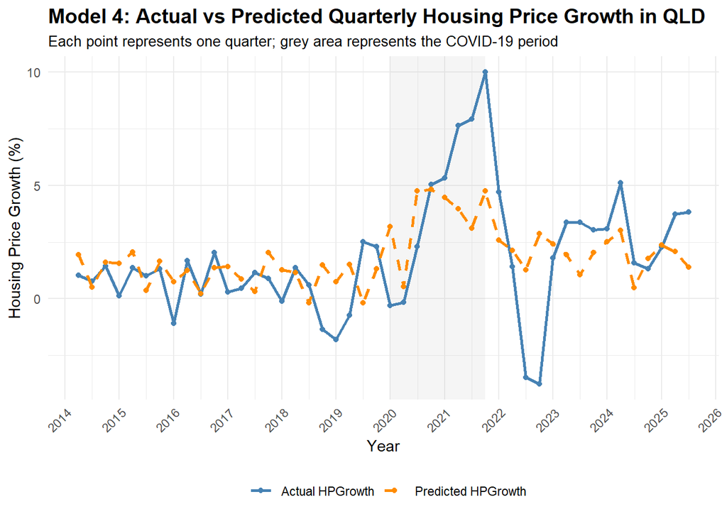

```r
plot_state("QLD")
```

## SA

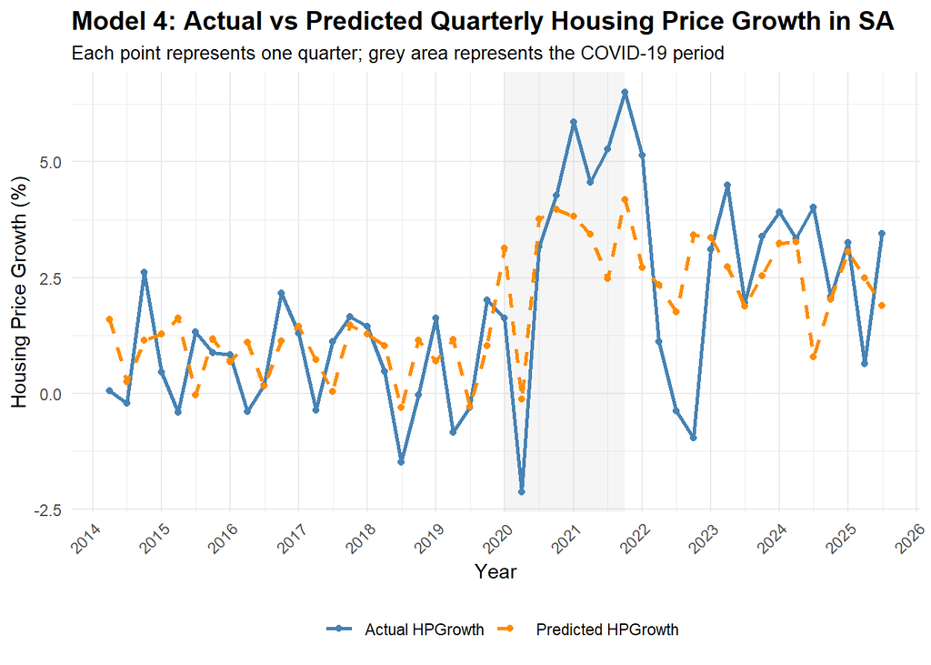

```r
plot_state("SA")
```

## WA

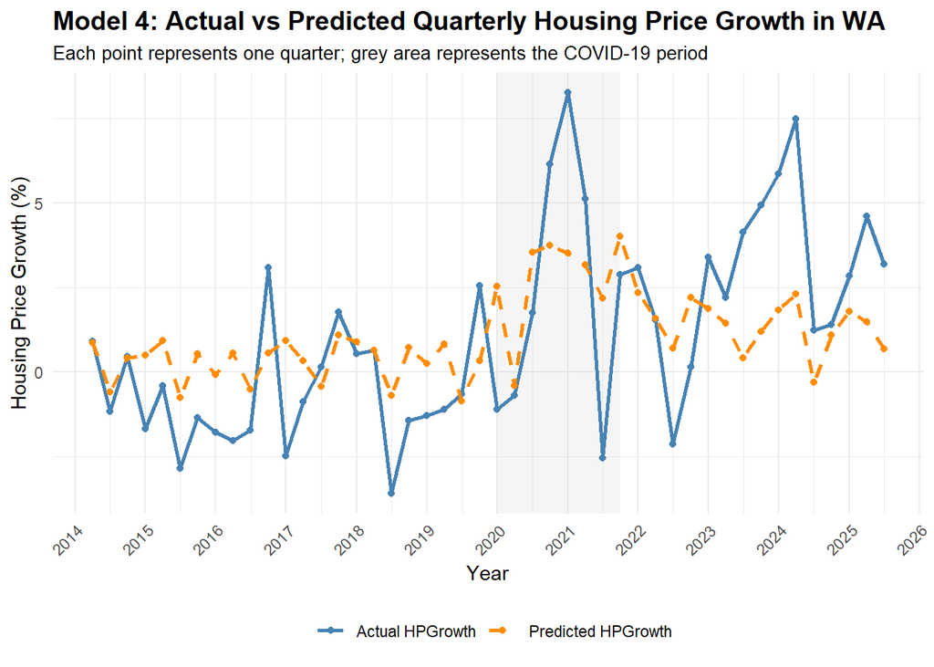

```r
plot_state("WA")
```

# 6. Final Conclusion

The regression results show that Model 4 is the preferred model. It includes interest rate, inflation, net overseas migration, household income, COVID-19, quarterly seasonal controls, time trend, and state controls. Model 4 has the highest adjusted R-squared value before adding the election dummy. Model 5 has a slightly higher R-squared, but its adjusted R-squared decreases and the election dummy is not statistically significant. Therefore, Model 4 provides the best balance between explanatory power, prediction accuracy, and model simplicity.